# Heart Failure Prediction

```r
#install.packages('tidymodels')
library(tidyverse)
library(naniar)
library(tidymodels)
library(janitor)
theme_set(theme_bw())
tidymodels_prefer()
```

## Load in and clean the data

```r
df <- read_csv('/Users/janakisajja/Downloads/heart_failure_clinical_records_dataset.csv')
summary(df)
```

```
##       age           anaemia       creatinine_phosphokinase    diabetes
##  Min.   :40.00   Min.   :0.0000   Min.   :  23.0           Min.   :0.0000
##  1st Qu.:51.00   1st Qu.:0.0000   1st Qu.: 116.5           1st Qu.:0.0000
##  Median :60.00   Median :0.0000   Median : 250.0           Median :0.0000
##  Mean   :60.83   Mean   :0.4314   Mean   : 581.8           Mean   :0.4181
##  3rd Qu.:70.00   3rd Qu.:1.0000   3rd Qu.: 582.0           3rd Qu.:1.0000
##  Max.   :95.00   Max.   :1.0000   Max.   :7861.0           Max.   :1.0000
##  ejection_fraction high_blood_pressure   platelets      serum_creatinine
##  Min.   :14.00     Min.   :0.0000      Min.   : 25100   Min.   :0.500
##  1st Qu.:30.00     1st Qu.:0.0000      1st Qu.:212500   1st Qu.:0.900
##  Median :38.00     Median :0.0000      Median :262000   Median :1.100
##  Mean   :38.08     Mean   :0.3512      Mean   :263358   Mean   :1.394
##  3rd Qu.:45.00     3rd Qu.:1.0000      3rd Qu.:303500   3rd Qu.:1.400
##  Max.   :80.00     Max.   :1.0000      Max.   :850000   Max.   :9.400
##   serum_sodium        sex            smoking            time
##  Min.   :113.0   Min.   :0.0000   Min.   :0.0000   Min.   :  4.0
##  1st Qu.:134.0   1st Qu.:0.0000   1st Qu.:0.0000   1st Qu.: 73.0
##  Median :137.0   Median :1.0000   Median :0.0000   Median :115.0
##  Mean   :136.6   Mean   :0.6488   Mean   :0.3211   Mean   :130.3
##  3rd Qu.:140.0   3rd Qu.:1.0000   3rd Qu.:1.0000   3rd Qu.:203.0
##  Max.   :148.0   Max.   :1.0000   Max.   :1.0000   Max.   :285.0
##   DEATH_EVENT
##  Min.   :0.0000
##  1st Qu.:0.0000
##  Median :0.0000
##  Mean   :0.3211
##  3rd Qu.:1.0000
##  Max.   :1.0000
```

We can see from the summary that there are variables that are numeric that should be classified as factors.

```r
df <- df %>%
    mutate(anaemia = factor(anaemia, levels = c(0,1), labels = c('No','Yes')),
           diabetes = factor(diabetes, levels = c(0,1), labels = c('No','Yes')),
           high_blood_pressure = factor(high_blood_pressure,
                                           levels = c(0,1), labels = c('No','Yes')),
           sex = factor(sex, levels = c(0,1), labels = c('Female','Male')),
           smoking = factor(smoking, levels = c(0,1), labels = c('No','Yes')),
           death_event = factor(DEATH_EVENT,
                                   levels = c(0,1), labels = c('Alive','Deceased')))
```

```r
df$age_bin <- cut(df$age, breaks = c(30, 40, 50, 60, 70, 80, 90, 100))
df <- df %>%
  select(-age)
```

### Check for missing data

```r
(missing_data_df <- miss_var_summary(df))
```

```
## # A tibble: 14 x 3
##    variable                 n_miss pct_miss
##    <chr>                     <int>    <dbl>
##  1 anaemia                       0        0
##  2 creatinine_phosphokinase      0        0
##  3 diabetes                      0        0
##  4 ejection_fraction             0        0
##  5 high_blood_pressure           0        0
##  6 platelets                     0        0
##  7 serum_creatinine              0        0
##  8 serum_sodium                  0        0
##  9 sex                           0        0
## 10 smoking                       0        0
## 11 time                          0        0
## 12 DEATH_EVENT                   0        0
## 13 death_event                   0        0
## 14 age_bin                       0        0
```

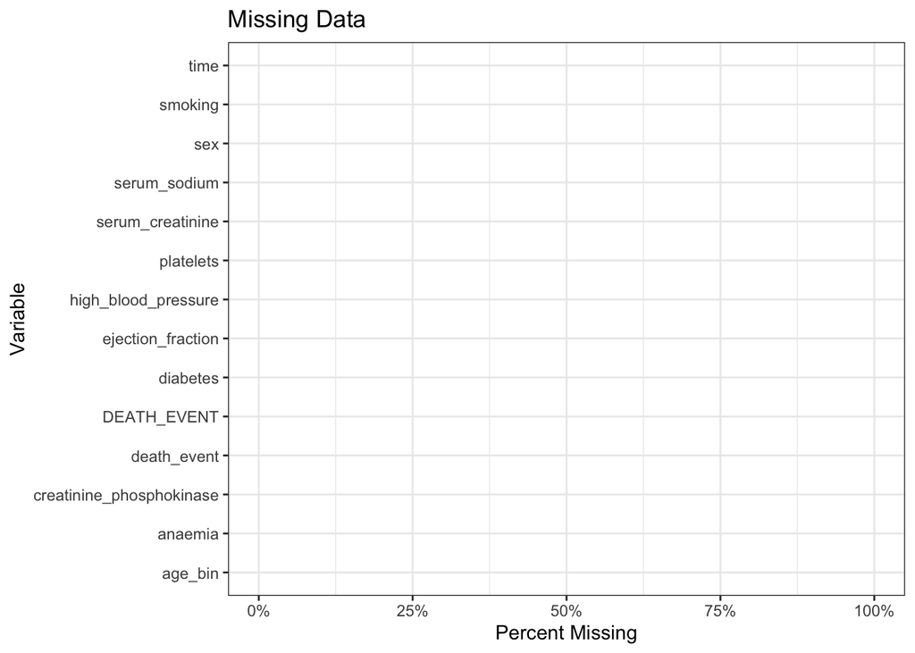

```r
ggplot(missing_data_df, aes(x = variable, y = pct_miss)) +
    geom_bar(stat = 'identity') +
    scale_y_continuous(labels = scales::percent, limits = c(0,1)) +
    coord_flip() +
    labs(title = 'Missing Data', x = 'Variable', y = 'Percent Missing')
```

There is no missing data.

## Exploratory Data Analysis

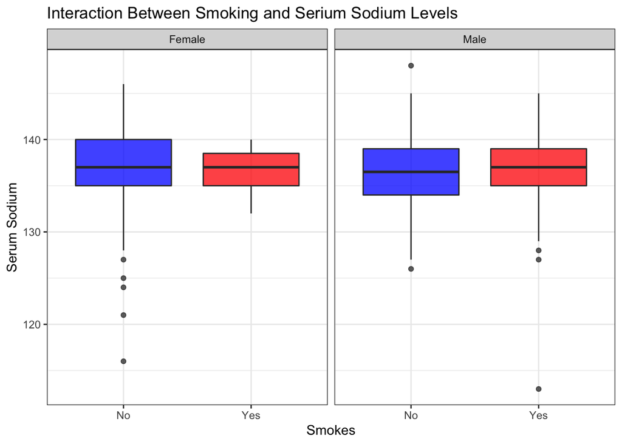

```r
ggplot(df, aes(x = smoking, y = serum_sodium, fill = smoking)) +
    geom_boxplot(alpha = .75) +
    labs(title = 'Interaction Between Smoking and Serium Sodium Levels',
         x = 'Smokes', y = 'Serum Sodium') +
  facet_wrap(~sex) +
  scale_fill_manual(values = c('blue','red')) +
  theme(legend.position = 'none')
```

It looks like smoking does not have an affect on a persons serum sodium levels regardless of that persons sex.

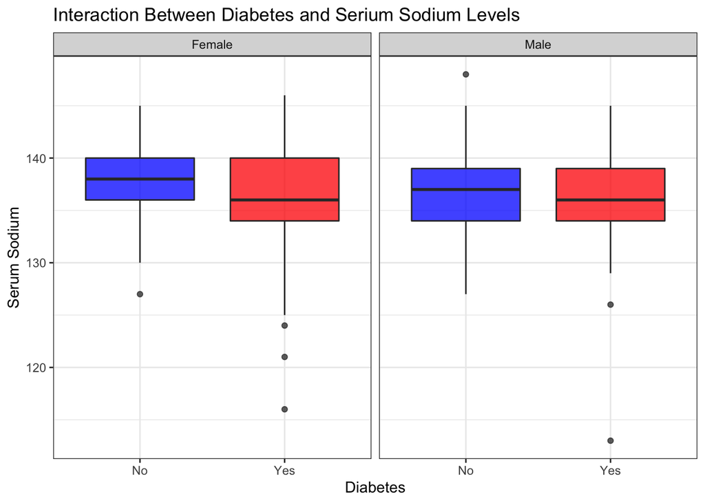

```r
ggplot(df, aes(x = diabetes, y = serum_sodium, fill = diabetes)) +
    geom_boxplot(alpha = .75) +
    labs(title = 'Interaction Between Diabetes and Serium Sodium Levels',
         x = 'Diabetes', y = 'Serum Sodium') +
  facet_wrap(~sex) +
  scale_fill_manual(values = c('blue','red')) +
  theme(legend.position = 'none')
```

Diabetes also does not seem to have an affect on a persons serum sodium levels regardless of sex.

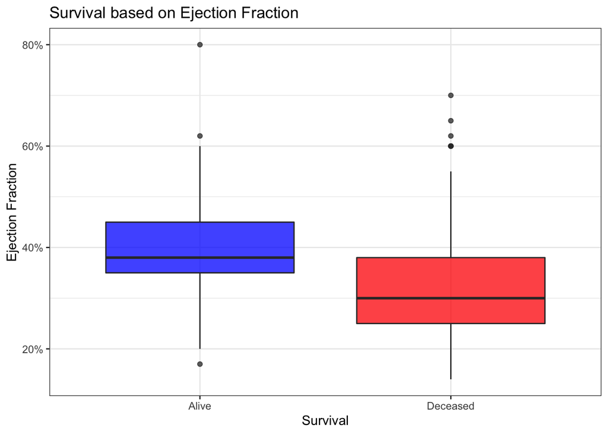

```r
ggplot(df, aes(x = death_event, y = ejection_fraction / 100, fill = death_event)) +
  geom_boxplot(alpha = .75) +
  labs(title = 'Survival based on Ejection Fraction', x = 'Survival',
       y = 'Ejection Fraction') +
  scale_y_continuous(labels = scales::percent) +
  scale_fill_manual(values = c('blue','red')) +
  theme(legend.position = 'none')
```

Ejection fraction is defined as the percentage of blood leaving the heart at each contraction. Based off this plot, it looks like a higher ejection fraction means a higher chance of survival. An article from the [clevland clinic](https://my.clevelandclinic.org/health/articles/16950-ejection-fraction#:~:text=A%20normal%20left%20ventricular%20ejection,how%20well%20your%20treatment%20works.) describes that the ejection fraction of a healthy person without heart failure should range from 55% to 70%. This would support the idea that a higher ejection fraction would lead to a better chance of survival.

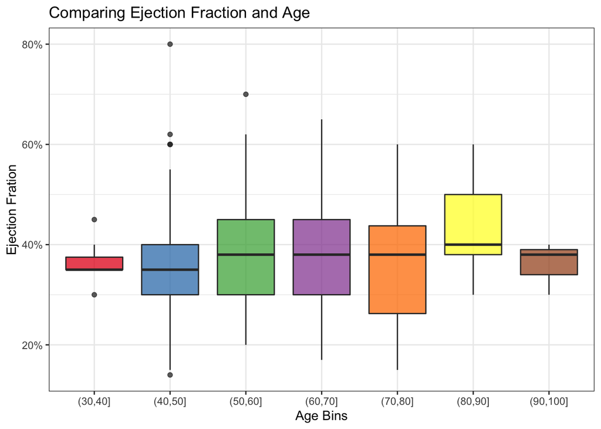

```r
ggplot(df, aes(x = age_bin, y = ejection_fraction / 100, fill = age_bin)) +
  geom_boxplot(alpha = .75) +
  labs(title = 'Comparing Ejection Fraction and Age', x = 'Age Bins',
       y = 'Ejection Fration') +
  scale_fill_brewer(palette = 'Set1') +
  scale_y_continuous(labels = scales::percent) +
  theme(legend.position = 'none')
```

Ejection Fraction seems to be relatively constant across all age groups in the data.

## Modeling

For the modeling process, I am going to use a logistic regression as a baseline model. I am also going to run randomForest and XGBoost models using the tidymodels package.

Splitting the data into training and testing sets and creating a cross validation object to split the training data into 10 groups.

```r
set.seed(42)
split <- initial_split(df, prop = .75, strata = death_event)
train_data <- training(split)
test_data <- testing(split)

k_folds <- vfold_cv(train_data, 10)
```

```r
tidy_recipe <- recipe(death_event~., data = train_data) %>%
  step_normalize(all_numeric()) %>%
  step_dummy(all_nominal(), -all_outcomes())

tidy_recipe %>% prep()
```

```
## Data Recipe
##
## Inputs:
##
##       role #variables
##    outcome          1
##  predictor         13
##
## Training data contained 224 data points and no missing data.
##
## Operations:
##
## Centering and scaling for creatinine_phosphokinase, ... [trained]
## Dummy variables from anaemia, diabetes, high_blood_pressure, sex, ... [trained]
```

```r
logistic_regression_model <- logistic_reg() %>%
  set_mode('classification') %>%
  set_engine('glm')

randomForest_model <- rand_forest(mtry = tune(), trees = tune(), min_n = tune()) %>%
  set_mode('classification') %>%
  set_engine('randomForest')

XGBoost_model <- boost_tree(mtry = tune(), trees = tune(), min_n = tune(),
                      tree_depth = tune(), learn_rate = tune()) %>%
  set_mode('classification') %>%
  set_engine('xgboost')
```

Created 3 models using the tidymodels package. The logistic regression model has no tuning paramters and will be used as the baseline model to evaluate other models. The 2 other models being used are a randomForest and XGBoost with both having tuned parameters.

Below is a function to creat a workflow object. It takes in a recipe in a model and creates an object that aggregates information in order to fit and predict from a model.

```r
create_workflow <- function(recipe, model) {
  tidy_workflow <- workflow() %>%
    add_recipe(recipe) %>%
    add_model(model)
}
```

```r
logistic_wf <- create_workflow(tidy_recipe, logistic_regression_model)
randomForest_wf <- create_workflow(tidy_recipe, randomForest_model)
XGBoost_wf <- create_workflow(tidy_recipe, XGBoost_model)
```

Below is a function to tune the models. The function tune_grid from the tune package already does this, but I wrapped it inside of a function called tune_model for easier repitition.

```r
tune_model <- function(workflow, resamples = k_folds, grid = 5){
  tidy_tune <- tune_grid(workflow, resamples = resamples, grid = grid)
}
```

```r
#install.packages("randomForest", dependencies = T)
randomForest_tune <- tune_model(randomForest_wf)
```

```
## i Creating pre-processing data to finalize unknown parameter: mtry
```

```r
#install.packages("xgboost", dependencies = T)
XGBoost_tune <- tune_model(XGBoost_wf)
```

```
## i Creating pre-processing data to finalize unknown parameter: mtry
```

```r
logistic_reg <- fit_resamples(logistic_wf, k_folds)
```

[output not shown]

[output not shown]

[output not shown]

[output not shown]

[output not shown]

[output not shown]

[output not shown]

[output not shown]

[output not shown]

[output not shown]

```r
collect_metrics(logistic_reg)
```

```
## # A tibble: 2 x 6
##   .metric  .estimator  mean     n std_err .config
##   <chr>    <chr>      <dbl> <int>   <dbl> <chr>
## 1 accuracy binary         1    10       0 Preprocessor1_Model1
## 2 roc_auc  binary         1    10       0 Preprocessor1_Model1
```

```r
tuned_randomForest <- randomForest_tune %>% select_best('roc_auc')
tuned_XGBoost <- XGBoost_tune %>% select_best('roc_auc')
```

```r
finalized_randomForest <- finalize_model(randomForest_model, tuned_randomForest)
finalized_XGBoost <- finalize_model(XGBoost_model, tuned_XGBoost)
```

Since the model is now finalized with tuned parameters and the best model has been selected using the select_best function, the final model needs to be passed through a final workflow before using it on the testing data.

```r
final_workflow <- function(recipe, final_model){
  final_workflow <- workflow() %>%
    add_recipe(recipe) %>%
    add_model(final_model)
}
```

```r
final_randomForest_model <- final_workflow(tidy_recipe, finalized_randomForest)
final_XGBoost <- final_workflow(tidy_recipe, finalized_XGBoost)
```

```r
test_randomForest <- final_randomForest_model %>% last_fit(split) %>% collect_metrics()
test_XGBoost <- final_XGBoost %>% last_fit(split) %>% collect_metrics()
```

```r
logistic_wf %>% last_fit(split) %>% collect_metrics()
```

```
## ! train/test split: preprocessor 1/1, model 1/1: glm.fit: algorithm did not converge
```

```
## # A tibble: 2 x 4
##   .metric  .estimator .estimate .config
##   <chr>    <chr>          <dbl> <chr>
## 1 accuracy binary             1 Preprocessor1_Model1
## 2 roc_auc  binary             1 Preprocessor1_Model1
```

```r
test_randomForest
```

```
## # A tibble: 2 x 4
##   .metric  .estimator .estimate .config
##   <chr>    <chr>          <dbl> <chr>
## 1 accuracy binary         0.973 Preprocessor1_Model1
## 2 roc_auc  binary         1     Preprocessor1_Model1
```

```r
test_XGBoost
```

```
## # A tibble: 2 x 4
##   .metric  .estimator .estimate .config
##   <chr>    <chr>          <dbl> <chr>
## 1 accuracy binary         0.987 Preprocessor1_Model1
## 2 roc_auc  binary         1     Preprocessor1_Model1
```

```r
test_data %>% count(death_event)
```

```
## # A tibble: 2 x 2
##   death_event     n
##   <fct>       <int>
## 1 Alive          51
## 2 Deceased       24
```

## Results

Since the data is inbalanced with there being about 2x as many patients that are alive than deceased in the test data, I will use the roc_auc score as the primary metric to determine which model best fits the data.